# CITS4009 - Project 1

## Earnings by category

Next we analyze how earnings differ across different YouTube channel categories.

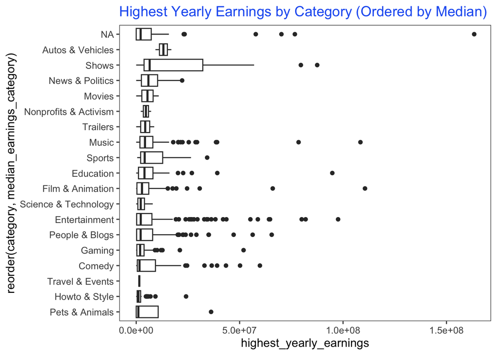

```r
# Calculate median for each category
df$median_earnings_category <- with(df, ave(highest_yearly_earnings, category, FUN=median))

# Create the boxplot
ggplot(df, aes(x = reorder(category, median_earnings_category), y = highest_yearly_earnings)) +
  geom_boxplot() +
  coord_flip() +
  ggtitle("Highest Yearly Earnings by Category (Ordered by Median)") +
  color_theme
```

All categories have similar median values except Autos & Vehicles, whose median is significantly larger than others. Pets & Animals channel has the smallest median value of highest yearly earnings.

## Earnings by country

```r
# Compute median values using dplyr
result <- df %>%
  group_by(Country) %>%
  summarise(median_earnings = median(highest_yearly_earnings, na.rm = TRUE))
result
```

```
## # A tibble: 50 × 2
##    Country     median_earnings
##    <chr>                 <dbl>
##  1 Afghanistan            0
##  2 Andorra                4
##  3 Argentina        9200000
##  4 Australia        1000000
##  5 Bangladesh             0.05
##  6 Barbados         8800000
##  7 Brazil           2200000
##  8 Canada           2400000
##  9 Chile            3200000
## 10 China            1100000
## # ℹ 40 more rows
```

We can analyse the highest yearly earnings of the top 995 YouTube channels by country.

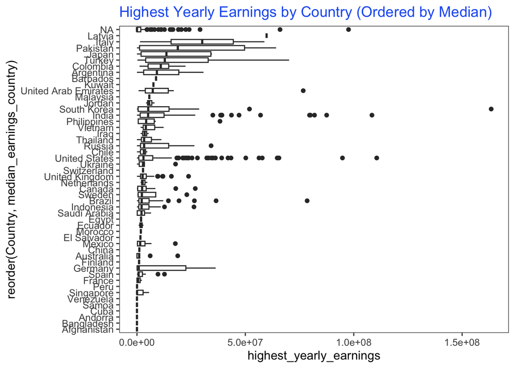

```r
# Calculate median for each country
df$median_earnings_country <- with(df, ave(highest_yearly_earnings, Country, FUN=median))

# Create the boxplot
ggplot(df, aes(x = reorder(Country, median_earnings_country), y = highest_yearly_earnings)) +
  geom_boxplot() +
  coord_flip() +
  ggtitle("Highest Yearly Earnings by Country (Ordered by Median)") +
  color_theme
```

The popular channel from Latvia has a distinctively higher value of highest yearly earnings among all the countries.

# EDA: Geospatial information

With longitude and latitude provided in the dataset, we are able to visualise the country distribution in the aspect of earnings analysis.

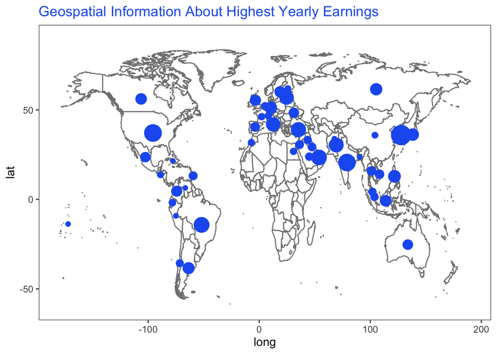

```r
# Data preparation
visit.x<-df$Longitude
visit.y<-df$Latitude

mp<-NULL #Create an empty map
mapworld<-borders("world",colour = "gray50",fill="white") #Draw the map
mp<-ggplot()+mapworld+ylim(-60,90)
mp2<-mp+geom_point(aes(x=visit.x,y=visit.y,size=df$highest_yearly_earnings),color=my_color)+
  scale_size(range=c(2,9))+
  ggtitle("Geospatial Information About Highest Yearly Earnings")+
  theme(plot.title=element_text(size=25,color="red",face="italic"))+
  theme_grey(base_size = 32)
mp3<-mp2+color_theme+theme(legend.position = "none")
mp3
```

# EDA: Trend by time